# Practical Lab 2: Multivariate Linear Regression, Non-Parametric Models and Cross-Validation

### *The lab's objective is to create a model that can most accurately predict the risk of diabetes advancing. This will serve as a screening tool to assist physicians in identifying people who pose a risk.*

# **_**

## In this lab we will evaluate the models using;

1. R-squared
2. Mean Absolute Percentage Error (MAPE)
3. Mean Absolute Error (MAE) metrics

# **_**

### 1-2) Importing the requirements and the dataset

```python
import pandas as pd
import matplotlib.pyplot as plt
import pylab as pl
import numpy as np
%matplotlib inline
import seaborn as sns

from sklearn import datasets
from sklearn.linear_model import LinearRegression
from sklearn.preprocessing import PolynomialFeatures
from sklearn.neighbors import KNeighborsRegressor
from sklearn.model_selection import train_test_split
from sklearn.metrics import mean_absolute_error, mean_absolute_percentage_error,r2_score
```

```python
diabetes_data = datasets.load_diabetes(as_frame=True,scaled=False)
df = diabetes_data.frame
df.head()
```

|  | age | sex | bmi | bp | s1 | s2 | s3 | s4 | s5 | s6 | target |
| --- | --- | --- | --- | --- | --- | --- | --- | --- | --- | --- | --- |
| 0 | 59.00 | 2.00 | 32.10 | 101.00 | 157.00 | 93.20 | 38.00 | 4.00 | 4.86 | 87.00 | 151.00 |
| 1 | 48.00 | 1.00 | 21.60 | 87.00 | 183.00 | 103.20 | 70.00 | 3.00 | 3.89 | 69.00 | 75.00 |
| 2 | 72.00 | 2.00 | 30.50 | 93.00 | 156.00 | 93.60 | 41.00 | 4.00 | 4.67 | 85.00 | 141.00 |
| 3 | 24.00 | 1.00 | 25.30 | 84.00 | 198.00 | 131.40 | 40.00 | 5.00 | 4.89 | 89.00 | 206.00 |
| 4 | 50.00 | 1.00 | 23.00 | 101.00 | 192.00 | 125.40 | 52.00 | 4.00 | 4.29 | 80.00 | 135.00 |

```python
pd.options.display.float_format = '{:.2f}'.format
df.describe()
```

|  | age | sex | bmi | bp | s1 | s2 | s3 | s4 | s5 | s6 | target |
| --- | --- | --- | --- | --- | --- | --- | --- | --- | --- | --- | --- |
| count | 442.00 | 442.00 | 442.00 | 442.00 | 442.00 | 442.00 | 442.00 | 442.00 | 442.00 | 442.00 | 442.00 |
| mean | 48.52 | 1.47 | 26.38 | 94.65 | 189.14 | 115.44 | 49.79 | 4.07 | 4.64 | 91.26 | 152.13 |
| std | 13.11 | 0.50 | 4.42 | 13.83 | 34.61 | 30.41 | 12.93 | 1.29 | 0.52 | 11.50 | 77.09 |
| min | 19.00 | 1.00 | 18.00 | 62.00 | 97.00 | 41.60 | 22.00 | 2.00 | 3.26 | 58.00 | 25.00 |
| 25% | 38.25 | 1.00 | 23.20 | 84.00 | 164.25 | 96.05 | 40.25 | 3.00 | 4.28 | 83.25 | 87.00 |
| 50% | 50.00 | 1.00 | 25.70 | 93.00 | 186.00 | 113.00 | 48.00 | 4.00 | 4.62 | 91.00 | 140.50 |
| 75% | 59.00 | 2.00 | 29.27 | 105.00 | 209.75 | 134.50 | 57.75 | 5.00 | 5.00 | 98.00 | 211.50 |
| max | 79.00 | 2.00 | 42.20 | 133.00 | 301.00 | 242.40 | 99.00 | 9.09 | 6.11 | 124.00 | 346.00 |

# **_**

## 3) EDA

### Column description

1. age age in years
2. sex
3. bmi body mass index
4. bp average blood pressure
5. s1 tc, total serum cholesterol
6. s2 ldl, low-density lipoproteins
7. s3 hdl, high-density lipoproteins
8. s4 tch, total cholesterol / HDL
9. s5 ltg, possibly log of serum triglycerides level
10. s6 glu, blood sugar level

```python
correlation_matrix = df.corr()
correlation_matrix
```

|  | age | sex | bmi | bp | s1 | s2 | s3 | s4 | s5 | s6 | target |
| --- | --- | --- | --- | --- | --- | --- | --- | --- | --- | --- | --- |
| age | 1.00 | 0.17 | 0.19 | 0.34 | 0.26 | 0.22 | -0.08 | 0.20 | 0.27 | 0.30 | 0.19 |
| sex | 0.17 | 1.00 | 0.09 | 0.24 | 0.04 | 0.14 | -0.38 | 0.33 | 0.15 | 0.21 | 0.04 |
| bmi | 0.19 | 0.09 | 1.00 | 0.40 | 0.25 | 0.26 | -0.37 | 0.41 | 0.45 | 0.39 | 0.59 |
| bp | 0.34 | 0.24 | 0.40 | 1.00 | 0.24 | 0.19 | -0.18 | 0.26 | 0.39 | 0.39 | 0.44 |
| s1 | 0.26 | 0.04 | 0.25 | 0.24 | 1.00 | 0.90 | 0.05 | 0.54 | 0.52 | 0.33 | 0.21 |
| s2 | 0.22 | 0.14 | 0.26 | 0.19 | 0.90 | 1.00 | -0.20 | 0.66 | 0.32 | 0.29 | 0.17 |
| s3 | -0.08 | -0.38 | -0.37 | -0.18 | 0.05 | -0.20 | 1.00 | -0.74 | -0.40 | -0.27 | -0.39 |
| s4 | 0.20 | 0.33 | 0.41 | 0.26 | 0.54 | 0.66 | -0.74 | 1.00 | 0.62 | 0.42 | 0.43 |
| s5 | 0.27 | 0.15 | 0.45 | 0.39 | 0.52 | 0.32 | -0.40 | 0.62 | 1.00 | 0.46 | 0.57 |
| s6 | 0.30 | 0.21 | 0.39 | 0.39 | 0.33 | 0.29 | -0.27 | 0.42 | 0.46 | 1.00 | 0.38 |
| target | 0.19 | 0.04 | 0.59 | 0.44 | 0.21 | 0.17 | -0.39 | 0.43 | 0.57 | 0.38 | 1.00 |

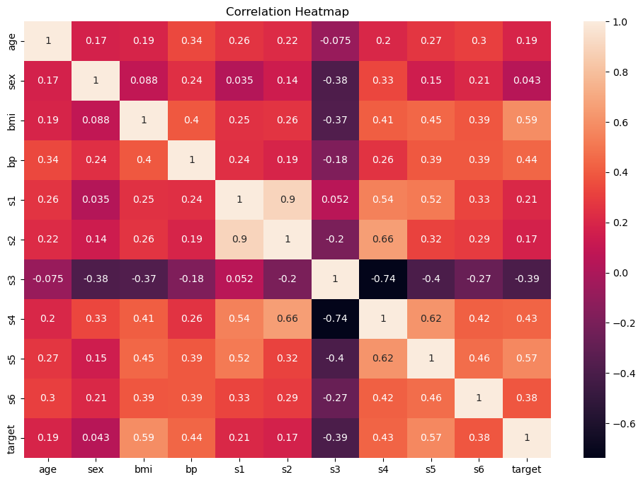

```python
import seaborn as sns
plt.figure(figsize=(12, 8))
sns.heatmap(correlation_matrix,annot=True)
plt.title('Correlation Heatmap')
plt.show()
```

##### The **bmi** and the **s5** ("ltg, possibly log of serum triglycerides level") has the highest corelation with the **target**

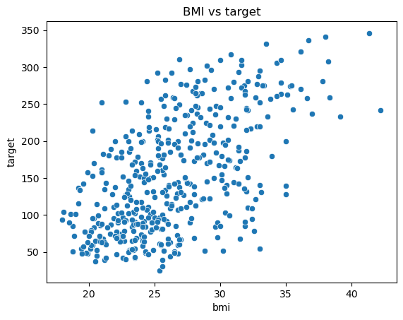

```python
sns.scatterplot(x = df.bmi, y = df.target)
plt.title('BMI vs target')
plt.show()
```

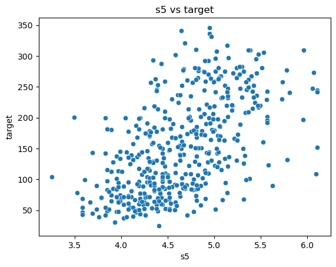

```python
sns.scatterplot(x = df.s5, y = df.target)
plt.title('s5 vs target')
plt.show()
```

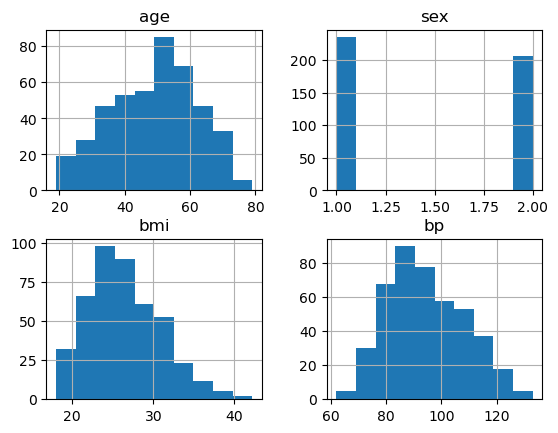

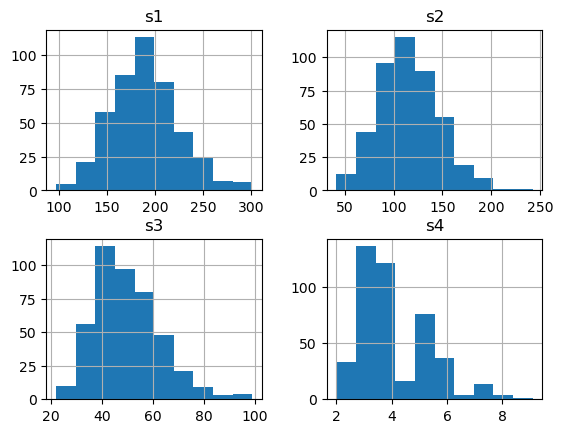

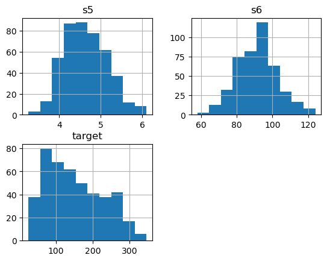

```python
#visiulaixing to understand how the data is distributed
plt.figure(figsize=(12, 8))
Viz1 = df[['age','sex','bmi','bp']]
Viz1.hist()
Viz2 = df[['s1','s2','s3','s4']]
Viz2.hist()
Viz3 = df[['s5','s6','target']]
Viz3.hist()
plt.show()
```

### *These plots show how values are distributed in each column*

# **_**

### 5) splitting the dataset into 3 splits;

1. train split
2. validation split
3. test split

```python
import numpy as np
import pandas as pd
dataset = np.random.rand(len(df)) < 0.75
train = df[dataset]
remaining = df[~dataset]
validation_test_split = np.random.rand(len(remaining)) < (10 / 25)
validation = remaining[validation_test_split]

test = remaining[~validation_test_split]

print("Train size:", len(train))
print("Validation size:", len(validation))
print("Test size:", len(test))
```

```
Train size: 334
Validation size: 42
Test size: 66
```

# **_**

### 6-7-8) Creating ,plotting, evaluating and choosing the best model

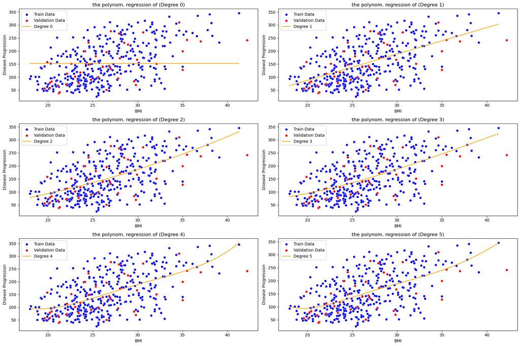

|  | Degree | MAE Train | MAE Validation | MAPE Train (%) | MAPE Validation (%) | R² Train | R² Validation |
| --- | --- | --- | --- | --- | --- | --- | --- |
| 0 | 0 | 66.00 | 62.75 | 61.65 | 62.61 | 0.00 | -0.00 |
| 1 | 1 | 52.99 | 48.74 | 48.60 | 44.45 | 0.32 | 0.35 |
| 2 | 2 | 52.67 | 50.72 | 48.32 | 45.96 | 0.32 | 0.31 |
| 3 | 3 | 52.63 | 50.57 | 48.26 | 45.97 | 0.32 | 0.32 |
| 4 | 4 | 52.53 | 50.98 | 48.08 | 45.90 | 0.32 | 0.28 |
| 5 | 5 | 52.50 | 50.52 | 48.07 | 45.52 | 0.32 | 0.30 |

```python
X_train = train[['bmi']]
y_train = train['target']
X_validation = validation[['bmi']]
y_validation = validation['target']

#my table to store te results
results = []

plt.figure(figsize=(18, 12))


for degree in range(6):

    poly = PolynomialFeatures(degree=degree)
    X_train_poly = poly.fit_transform(X_train)
    X_val_poly = poly.transform(X_validation)

    model = LinearRegression()
    model.fit(X_train_poly, y_train)

    y_train_pred = model.predict(X_train_poly)
    y_val_pred = model.predict(X_val_poly)

    mae_train = mean_absolute_error(y_train, y_train_pred)
    mae_val = mean_absolute_error(y_validation, y_val_pred)
    mape_train = mean_absolute_percentage_error(y_train, y_train_pred) * 100
    mape_val = mean_absolute_percentage_error(y_validation, y_val_pred) * 100
    r2_train = r2_score(y_train, y_train_pred)
    r2_val = r2_score(y_validation, y_val_pred)

    # now I will add the results to the results table
    results.append({
        'Degree': degree,
        'MAE Train': mae_train,
        'MAE Validation': mae_val,
        'MAPE Train (%)': mape_train,
        'MAPE Validation (%)': mape_val,
        'R² Train': r2_train,
        'R² Validation': r2_val
    })

    plt.subplot(3, 2, degree + 1)
    sns.scatterplot(x=X_train['bmi'], y=y_train, color='blue', label='Train Data')
    sns.scatterplot(x=X_validation['bmi'], y=y_validation, color='red', label='Validation Data')

    x_range = np.linspace(X_train['bmi'].min(), X_train['bmi'].max(), 100).reshape(-1, 1)
    x_range_poly = poly.transform(x_range)
    y_range_pred = model.predict(x_range_poly)

    plt.plot(x_range, y_range_pred, color='orange', label=f'Degree {degree}')


    plt.title(f'the polynom. regression of (Degree {degree})')
    plt.xlabel('BMI')
    plt.ylabel('Disease Progression')
    plt.legend()


plt.tight_layout()
plt.show()

results_df = pd.DataFrame(results)
results_df
```

### *I have plotted the BMI against Disease Progression("target") with degrees from **0** to **5***

# **_**

### 9) Model 5 is evaluated on the test set

```python
X_test = test[['bmi']]
y_test = test['target']

poly = PolynomialFeatures(degree=5)
X_test_poly = poly.fit_transform(X_test)

model = LinearRegression()
model.fit(X_train_poly, y_train)
y_test_pred = model.predict(X_test_poly)

# metics
r2_test = r2_score(y_test, y_test_pred)
mae_test = mean_absolute_error(y_test, y_test_pred)
mape_test = mean_absolute_percentage_error(y_test, y_test_pred) * 100

res_test_df = pd.DataFrame({
    'Metric': ['R-Squared', 'Mean Absolute Error', 'Mean Absolute Percentage Error (%)'],
    'Test Set Results': [r2_test, mae_test, mape_test]
})

print("The R2 score,MAE and the MAPE values are")
res_test_df
```

```
The R2 score,MAE and the MAPE values are
```

|  | Metric | Test Set Results |
| --- | --- | --- |
| 0 | R-Squared | 0.48 |
| 1 | Mean Absolute Error | 47.71 |
| 2 | Mean Absolute Percentage Error (%) | 44.65 |

# **_**

### 10) Model 5 ("chosen model") fitted on the train, validation and test data points

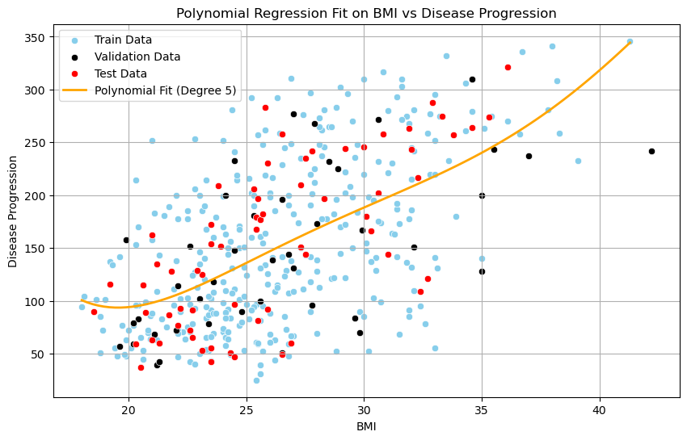

```python
poly = PolynomialFeatures(degree=5)
X_train_poly = poly.fit_transform(X_train)
model = LinearRegression().fit(X_train_poly, y_train)

x_range = np.linspace(train['bmi'].min(), train['bmi'].max(), 100).reshape(-1, 1)
y_range_pred = model.predict(poly.transform(x_range))

plt.figure(figsize=(10, 6))

sns.scatterplot(x=train['bmi'], y=y_train, color='skyblue', label='Train Data')
sns.scatterplot(x=validation['bmi'], y=validation['target'], color='black', label='Validation Data')
sns.scatterplot(x=test['bmi'], y=test['target'], color='red', label='Test Data')

plt.plot(x_range, y_range_pred, color='orange', label='Polynomial Fit (Degree 5)', linewidth=2)


plt.title('Polynomial Regression Fit on BMI vs Disease Progression')
plt.xlabel('BMI')
plt.ylabel('Disease Progression')
plt.legend()
plt.grid()
plt.show()
```

# **_**

### 11) equation of the best model

```python
intercept = model.intercept_
coefficients = model.coef_

equation = f"y = {intercept:.2f}"

for i in range(1, len(coefficients)):
    equation += f" + ({coefficients[i]:.2f} * x^{i})"

print("chosen model equatin :")
print(equation)
```

```
chosen model equatin :
y = 5115.34 + (-855.12 * x^1) + (56.15 * x^2) + (-1.79 * x^3) + (0.03 * x^4) + (-0.00 * x^5)
```

# **_**

### 12) expected diabetes progression for a BMI value

```python
data = {
    'bmi': df['bmi'].tolist(),
    'target': df['target'].tolist()
}

df = pd.DataFrame(data)
avg_bmi = df['bmi'].mean()
std_bmi = df['bmi'].std()

y = df['target']

poly = PolynomialFeatures(degree=5)
X_poly = poly.fit_transform(df[['bmi']])
model = LinearRegression()
model.fit(X_poly, y)

# Inputting and predicting
bmi_value = 25
standardized_bmi = (bmi_value - avg_bmi) / std_bmi
stand_bmi_poly = poly.transform([[bmi_value]])
predicted_progression = model.predict(stand_bmi_poly)
print("Expected diabetes progression = ",predicted_progression[0], "for BMI of",bmi_value)
```

```
Expected diabetes progression =  138.52898932272 for BMI of 25
```

# **_**

### 13) How many trainable parameters are we fitting for each of the models

```python
X = df[['bmi']]
y = df['target']

poly = PolynomialFeatures(degree=5)
X_poly = poly.fit_transform(X)
model = LinearRegression(fit_intercept=False)
model.fit(X_poly, y)

num_features = X_poly.shape[1]
num_parameters = num_features

print("Number of Trainable Parameters:", num_parameters)
feature_names = poly.get_feature_names_out()
print("Feature Names:", feature_names)
```

```
Number of Trainable Parameters: 6
Feature Names: ['1' 'bmi' 'bmi^2' 'bmi^3' 'bmi^4' 'bmi^5']
```

### *In this example, I have Created the polynomial features, then I have removed the intercept and fitted the linear regression model, after that, I got the number of features and calculated the trainable parameters, finally, the outputs are printed. I have done this for only degree 5 to view the trainable parameters, the same methodology applies for other degrees*

### *The rule for this algorithm is that for every (n) degrees, there will be (n+1) parameters*

# **_**

### 14) conclusion section

### *In conclusion, my model performs well with most data but struggles with extreme values, leading to unrealistic predictions. It’s limited by the assumptions of polynomial regression and may not generalize well to new data. I need to explore other models for better accuracy and robustness.*

# **_**

## Part 3

```python
X = df[['bmi']]
y = df['target']


def polynomial_model(degree):
    poly = PolynomialFeatures(degree=degree)
    X_poly_train = poly.fit_transform(X_train)
    X_poly_test = poly.transform(X_test)

    model = LinearRegression()
    model.fit(X_poly_train, y_train)

    y_pred = model.predict(X_poly_test)

    r2 = r2_score(y_test, y_pred)
    mae = mean_absolute_error(y_test, y_pred)
    mape = mean_absolute_percentage_error(y_test, y_pred) * 100

    return r2, mae, mape
results_poly = []
for degree in [8, 10]:
    r2, mae, mape = polynomial_model(degree)
    results_poly.append((degree, r2, mae, mape))

results_poly_df = pd.DataFrame(results_poly, columns=['Degree', 'R-Squared', 'MAE', 'MAPE'])
print("Polynomial Models Results on Test Set:")
results_poly_df
```

```
Polynomial Models Results on Test Set:
```

|  | Degree | R-Squared | MAE | MAPE |
| --- | --- | --- | --- | --- |
| 0 | 8 | 0.49 | 47.43 | 44.63 |
| 1 | 10 | 0.49 | 47.39 | 44.76 |

### 2. Two Decision trees with degrees of **2** and **5**

```python
def evaluate_decision_tree(max_depth):
    model = DecisionTreeRegressor(max_depth=max_depth)
    model.fit(X_train, y_train)

    y_pred = model.predict(X_test)
    r2 = r2_score(y_test, y_pred)
    mae = mean_absolute_error(y_test, y_pred)
    mape = mean_absolute_percentage_error(y_test, y_pred) * 100

    return r2, mae, mape

results_tree = []
for depth in [2, 5]:
    r2, mae, mape = evaluate_decision_tree(depth)
    results_tree.append((depth, r2, mae, mape))

results_destree_df = pd.DataFrame(results_tree, columns=['Max Depth', 'R-Squared', 'MAE', 'MAPE'])
print("\nDecision Tree Models Results:")
results_destree_df
```

```
Decision Tree Models Results:
```

|  | Max Depth | R-Squared | MAE | MAPE |
| --- | --- | --- | --- | --- |
| 0 | 2 | 0.50 | 45.95 | 43.39 |
| 1 | 5 | 0.39 | 50.42 | 47.31 |

```python
def evaluate_knn(k):
    model = KNeighborsRegressor(n_neighbors=k)
    model.fit(X_train, y_train)

    y_pred = model.predict(X_test)
    r2 = r2_score(y_test, y_pred)
    mae = mean_absolute_error(y_test, y_pred)
    mape = mean_absolute_percentage_error(y_test, y_pred) * 100

    return r2, mae, mape


results_knn = []
for k in [2, 5]:
    r2, mae, mape = evaluate_knn(k)
    results_knn.append((k, r2, mae, mape))


results_knn_df = pd.DataFrame(results_knn, columns=['k', 'R-Squared', 'MAE', 'MAPE'])
print("\nkNN Models Results:")
results_knn_df
```

```
kNN Models Results:
```

|  | k | R-Squared | MAE | MAPE |
| --- | --- | --- | --- | --- |
| 0 | 2 | 0.14 | 58.20 | 55.18 |
| 1 | 5 | 0.32 | 53.69 | 49.55 |

```python
combined_results_df = pd.concat([results_poly_df, results_destree_df, results_knn_df], ignore_index=True)
combined_results_df
```

|  | Degree | R-Squared | MAE | MAPE | Max Depth | k |
| --- | --- | --- | --- | --- | --- | --- |
| 0 | 8.00 | 0.49 | 47.43 | 44.63 | NaN | NaN |
| 1 | 10.00 | 0.49 | 47.39 | 44.76 | NaN | NaN |
| 2 | NaN | 0.50 | 45.95 | 43.39 | 2.00 | NaN |
| 3 | NaN | 0.39 | 50.42 | 47.31 | 5.00 | NaN |
| 4 | NaN | 0.14 | 58.20 | 55.18 | NaN | 2.00 |
| 5 | NaN | 0.32 | 53.69 | 49.55 | NaN | 5.00 |

```python
combined_results_df = pd.concat([results_poly_df, results_destree_df, results_knn_df], ignore_index=True)

combined_results_df = pd.melt(combined_results_df, id_vars=['R-Squared', 'MAE', 'MAPE'],
                               value_vars=['Degree', 'Max Depth', 'k'],
                               var_name='Parameter', value_name='chosen')
combined_results_df = combined_results_df.dropna(subset=['chosen'])
combined_results_df.reset_index(drop=True, inplace=True)
print("Transformed DataFrame:")
combined_results_df
```

```
Transformed DataFrame:
```

|  | R-Squared | MAE | MAPE | Parameter | chosen |
| --- | --- | --- | --- | --- | --- |
| 0 | 0.49 | 47.43 | 44.63 | Degree | 8.00 |
| 1 | 0.49 | 47.39 | 44.76 | Degree | 10.00 |
| 2 | 0.50 | 45.95 | 43.39 | Max Depth | 2.00 |
| 3 | 0.39 | 50.42 | 47.31 | Max Depth | 5.00 |
| 4 | 0.14 | 58.20 | 55.18 | k | 2.00 |
| 5 | 0.32 | 53.69 | 49.55 | k | 5.00 |

### _After cleaning the dataset, I have removed the null values and extra columns. I have added 2 new columns ("Parameter" and "chosen").

### *parameter states the type of algorithm (degree = poly, Max depth = = Decision tree and K value = KNN)*

### *chosen indicates the chosen value (in degrees, Max depth or K value)*

### *In conclusion: Decision trees has the lowest MAE and MAPE values when Max depth=2, it also has the highest R-squared value. So after observing all those results, I think that the Decision tree algorithm with Max Depth = 2 had the best overall results*

# **_**

#### I have applied some of the techniques from a course I have learned from [IBM-Coursera](https://www.coursera.org/professional-certificates/ai-engineer).